# notebook

### Loading Libraries

```python
# --- Core Libraries ---
import pandas as pd
import numpy as np

# --- Visualization ---
import matplotlib.pyplot as plt
import seaborn as sns

pd.set_option('display.max_columns', 200)
pd.set_option('display.width', 2000)

sns.set_style("whitegrid")
```

## High AI Exposure by Education and Age

In this section, we use Statistics Canada’s experimental estimates of AI exposure to see **which workers are most exposed to AI-related job transformation**.

Our guiding research question is:

How is AI reshaping the Canadian job market?

To explore this, we draw on Appendix Tables A.1 (2016) and A.2 (2021) from *Experimental Estimates of Potential Artificial Intelligence Occupational Exposure in Canada*. These tables report, for employees aged 18–64:

- An **AI Occupational Exposure Index (AIOE)** for each group.
- A **potential complementarity** score, indicating whether AI is more likely to *complement* rather than replace their work.
- The share of workers in three categories:
  - **High exposure, low complementarity**
  - **High exposure, high complementarity**
  - **Low exposure**

These figures let us see how AI exposure is distributed across education and age, and how that distribution has shifted between 2016 and 2021, providing insight into which segments of the Canadian workforce are most directly affected by AI.

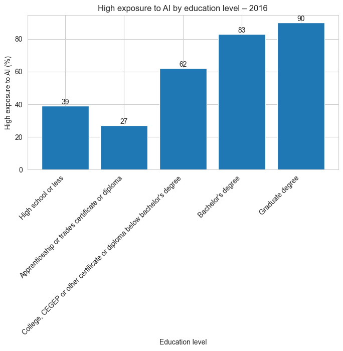

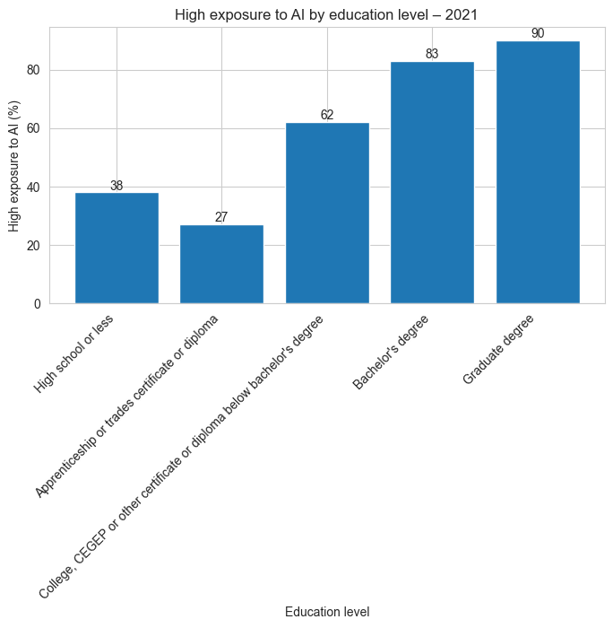

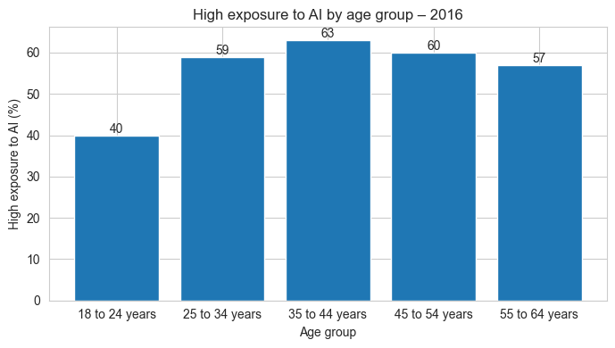

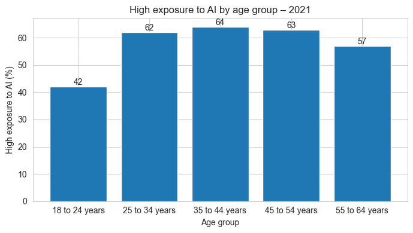

```python
# Load both years
a1 = pd.read_csv("data/appendix_A1_subset.csv")  # 2016
a2 = pd.read_csv("data/appendix_A2_subset.csv")  # 2021

# Add total high exposure percentage
for df in (a1, a2):
    df["High_exposure_total_pct"] = (
        df["High_exposure_low_comp_pct"] + df["High_exposure_high_comp_pct"]
    )


# High exposure to AI by education level – 2016
edu_2016 = a1[a1["Group"] == "Highest level of education"].copy()

# plotting 2016 data
plt.figure(figsize=(8, 4))
bars = plt.bar(edu_2016["Category"], edu_2016["High_exposure_total_pct"])
plt.xticks(rotation=45, ha="right")
plt.xlabel("Education level")
plt.ylabel("High exposure to AI (%)")
plt.title("High exposure to AI by education level – 2016")

# display values on top of bars
for bar in bars:
    yval = bar.get_height()
    plt.text(
        bar.get_x() + bar.get_width() / 2,
        yval,
        f"{yval:.0f}",
        ha="center",
        va="bottom"
    )

plt.tight_layout()
plt.show()

# High exposure to AI by education level – 2021
edu_2021 = a2[a2["Group"] == "Highest level of education"].copy()

# plotting 2021 data
plt.figure(figsize=(8, 4))
bars = plt.bar(edu_2021["Category"], edu_2021["High_exposure_total_pct"])
plt.xticks(rotation=45, ha="right")
plt.xlabel("Education level")
plt.ylabel("High exposure to AI (%)")
plt.title("High exposure to AI by education level – 2021")

# Display values on top of bars
for bar in bars:
    yval = bar.get_height()
    plt.text(
        bar.get_x() + bar.get_width() / 2,
        yval,
        f"{yval:.0f}",
        ha="center",
        va="bottom"
    )

plt.tight_layout()
plt.show()


# High exposure to AI by age group – 2016
age_2016 = a1[a1["Group"] == "Age"].copy()

# plotting 2016 data
plt.figure(figsize=(7, 4))
bars = plt.bar(age_2016["Category"], age_2016["High_exposure_total_pct"])
plt.xticks(rotation=0)
plt.xlabel("Age group")
plt.ylabel("High exposure to AI (%)")
plt.title("High exposure to AI by age group – 2016")

# Display values on top of bars
for bar in bars:
    yval = bar.get_height()
    plt.text(
        bar.get_x() + bar.get_width() / 2,
        yval,
        f"{yval:.0f}",
        ha="center",
        va="bottom"
    )

plt.tight_layout()
plt.show()

# High exposure to AI by age group – 2021
age_2021 = a2[a2["Group"] == "Age"].copy()

# plotting 2021 data
plt.figure(figsize=(7, 4))
bars = plt.bar(age_2021["Category"], age_2021["High_exposure_total_pct"])
plt.xticks(rotation=0)
plt.xlabel("Age group")
plt.ylabel("High exposure to AI (%)")
plt.title("High exposure to AI by age group – 2021")

# Display values on top of bars
for bar in bars:
    yval = bar.get_height()
    plt.text(
        bar.get_x() + bar.get_width() / 2,
        yval,
        f"{yval:.0f}",
        ha="center",
        va="bottom"
    )

plt.tight_layout()
plt.show()
```

Loading Dataset Cell 2

```
Loaded wages_2021.csv → (43000, 16)
Loaded wages_2022.csv → (43000, 17)
Loaded wages_2023.csv → (44376, 18)
Loaded wages_2024.csv → (44376, 21)
Combined dataset: (174752, 26)
After cleaning: (77938, 26)
```

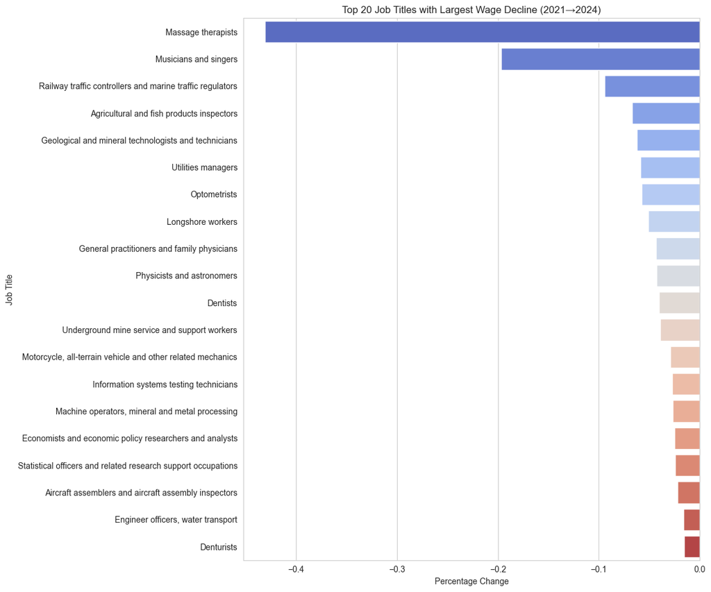

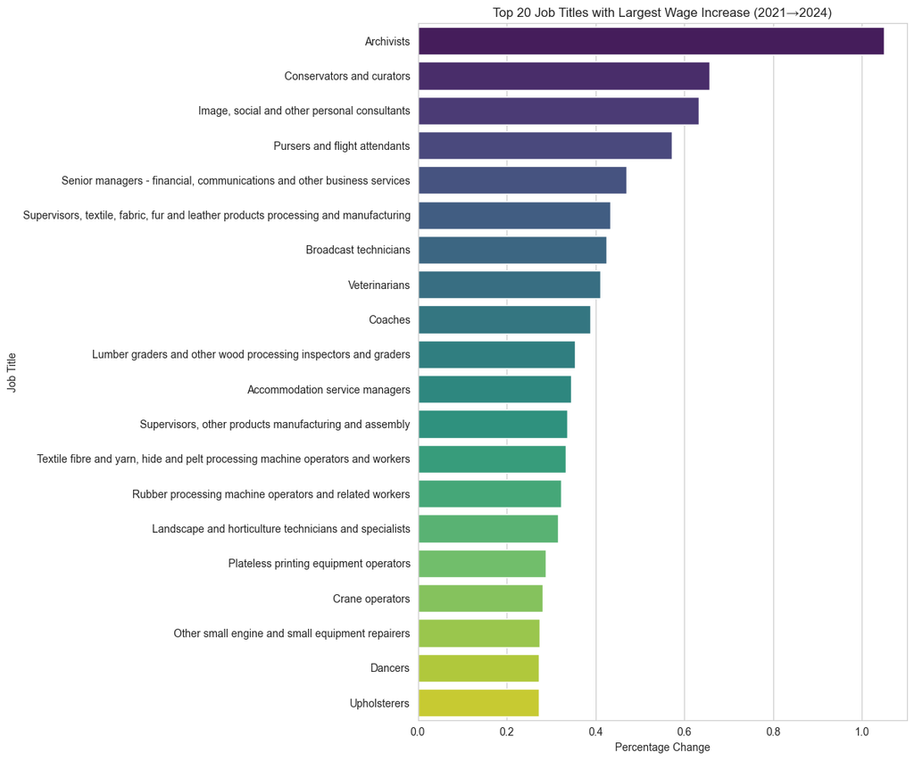

```python
years = [2021, 2022, 2023, 2024]
wage_dfs = {}

for y in years:
    wage_dfs[y] = pd.read_csv(f"data/wages_{y}.csv", low_memory=False)
    print(f"Loaded wages_{y}.csv → {wage_dfs[y].shape}")


# Normalize each year's dataframe

def normalize(df, year):
    df = df.copy()
    df['year'] = year

    # Standardize job title columns across different years
    title_map = {
        'NOC_Title': 'job_title',
        'NOC_TITLE_ENG': 'job_title',
        'NOC_Title_eng': 'job_title'
    }
    df = df.rename(columns=title_map)

    # Standardize shared wage columns
    colmap = {
        'NOC_CNP': 'noc_code',
        'Median_Wage_Salaire_Median': 'median_wage',
        'Annual_Wage_Flag_Salaire_annuel': 'annual_wage_flag',
        'PROV': 'province',
        'prov': 'province'
    }
    df = df.rename(columns=colmap)

    # Ensure required columns exist (avoid KeyErrors)
    required = ['year','job_title','noc_code','median_wage','annual_wage_flag','province']
    for col in required:
        if col not in df.columns:
            df[col] = np.nan

    # Annualize if hourly (flag = 0)
    df['median_wage_annualized'] = np.where(
        df['annual_wage_flag'] == 0,
        df['median_wage'] * 2080,
        df['median_wage']
    )

    return df

# Apply normalization
normalized_dfs = [normalize(wage_dfs[y], y) for y in years]

# Combine all years
all_years = pd.concat(normalized_dfs, ignore_index=True)

print("Combined dataset:", all_years.shape)
all_years.head()

# Clean data: remove rows with missing job titles or median wages <= 0
clean = all_years.dropna(subset=['job_title', 'median_wage_annualized'])
clean = clean[clean['median_wage_annualized'] > 0]

print("After cleaning:", clean.shape)
clean.head()

# Analyze wage trends by job title from 2021 to 2024
trend = (
    clean.groupby(['job_title','year'])['median_wage_annualized']
    .median()
    .unstack()
)

# Calculate percentage change from 2021 to 2024
trend['pct_change'] = (trend[2024] - trend[2021]) / trend[2021]

# Sort by percentage change
trend_sorted = trend.sort_values('pct_change')

# Display top 20 job titles with largest wage decline
trend_sorted.head(20)

# Visualize top 20 job titles with largest wage decline
plt.figure(figsize=(12, 10))
sns.barplot(
    data=trend_sorted.head(20).reset_index(),
    x='pct_change',
    y='job_title',
    palette='coolwarm'
)
plt.title("Top 20 Job Titles with Largest Wage Decline (2021→2024)")
plt.xlabel("Percentage Change")
plt.ylabel("Job Title")
plt.tight_layout()
plt.show()

# Visualize top 20 job titles with largest wage increase
trend_sorted_inc = trend.sort_values('pct_change', ascending=False)
plt.figure(figsize=(12, 10))
sns.barplot(
    data=trend_sorted_inc.head(20).reset_index(),
    x='pct_change',
    y='job_title',
    palette='viridis'
)
plt.title("Top 20 Job Titles with Largest Wage Increase (2021→2024)")
plt.xlabel("Percentage Change")
plt.ylabel("Job Title")
plt.tight_layout()
plt.show()
```

From 2021 to 2024, the Canadian labour market shows clear polarization:

Some occupations experienced large wage declines, often due to oversupply, part-time dynamics, or early automation/AI adoption.

Other occupations saw strong wage growth, particularly those in skilled trades, manufacturing, and emerging knowledge-based roles such as archiving or digital record management.

Overall, the data suggests that job vulnerability depends more on industry structure and labour supply than on AI alone. However, some wage declines — particularly among testing technicians, research support roles, and statistical assistants — likely reflect early AI-driven productivity gains.

# Next we will look at employemnet and unemployement (Annual, Statistics Canada)

```python
# Combine Employment dataset parts
files = [
    "data/14100117_part_aa.csv",
    "data/14100117_part_ab.csv",
    "data/14100117_part_ac.csv",
    "data/14100117_part_ad.csv"
]

# First file has header
df = pd.read_csv(files[0], engine='python', on_bad_lines='skip')

# Rest DO NOT have header — use the same column names as the first file
for f in files[1:]:
    temp = pd.read_csv(f, header=None, names=df.columns, engine='python', on_bad_lines='skip')
    df = pd.concat([df, temp], ignore_index=True)

# If first row is actually the real header
if df.columns[0] != "REF_DATE":
    df.columns = df.iloc[0]
    df = df[1:]

print("Combined employment dataset:", df.shape)
# Convert REF_DATE to datetime
df['REF_DATE'] = pd.to_datetime(df['REF_DATE'], errors='coerce')

# remove missing for all analyses
df = df.dropna(subset=['REF_DATE'])
df = df[df['REF_DATE'].notnull()]

# remove missing  age groups data
df = df[df['Age group'].notnull()]

# remove missing education degree
df = df[df['Educational degree'].notnull()]


EE_Wage_Trend = df.copy()
```

```
Combined employment dataset: (1848001, 18)
```

### Understanding this Dataset

What Each row represents: “In this month, how many people in this demographic group were employed / unemployed / in the labour force?”

It describes:

- A specific month and year
- A specific group of people (defined by age, gender, education)
- A specific labour force characteristic (employment, unemployment, etc.)
- And the number of people in that group

Meaning:

- In June 2023, in Canada, there were 183.5 thousand employed men aged 25 to 54 with a high school diploma.

What the Columns mean:

REF_DATE

- The date of the statistic (month/year).
- Example: "2022-05" = May 2022.

GEO

- Geographic region

DGUID

- Geographic identifier code
- Not needed for analysis.

Labour force characteristics

- Type of measure being reported.
- Population
- Labour force
- Employment
- Full-time employment
- Part-time employment
- Unemployment
- Unemployment rate
- Participation rate
- Employment rate

Educational degree

- No certificate / diploma
- High school graduate
- Postsecondary certificate
- Bachelor's degree
- University degree
- Total, all education levels

Gender

- Men
- Women
- Total – Gender

Age group

- 15 years and over
- 15 to 24 years
- 25 to 54 years
- 55 years and over

UOM (Unit of Measure)

- Usually: “Persons in thousands”
- Example: VALUE 21064.5 = 21,064.5 thousand people = 21,064,500 people

SCALAR_FACTOR / SCALAR_ID

- Scaling information for VALUE (e.g., “thousands”).
- We typically won’t need this, because VALUE is already scaled correctly.

VALUE

- The number for analyzing
- Examples: Employment = number of employed people, Unemployment = number of unemployed people, Labour force = total active workforce

STATUS / SYMBOL / TERMINATED

- Quality flags or suppressed data indicators.
- Not really useful

DECIMALS

- How many decimal places VALUE uses.

```python
# print out the unique labour force characteristics
print(EE_Wage_Trend['Labour force characteristics'].unique())
```

```
['Population' 'Labour force' 'Employment' 'Full-time employment'
 'Part-time employment' 'Unemployment' 'Not in labour force'
 'Unemployment rate' 'Participation rate' 'Employment rate']
```

```python
#Filter out the data year from 2021 onwards
EE_Wage_Trend['REF_DATE'] = pd.to_datetime(EE_Wage_Trend['REF_DATE'])
EE_Wage_Trend = EE_Wage_Trend[EE_Wage_Trend['REF_DATE'] >= '2021-01-01']

print(EE_Wage_Trend.tail())
```

```
          REF_DATE               GEO        DGUID Labour force characteristics       Educational degree  Gender          Age group      UOM  UOM_ID SCALAR_FACTOR  SCALAR_ID     VECTOR    COORDINATE  VALUE STATUS  SYMBOL  TERMINATED  DECIMALS
1847996 2025-09-01  British Columbia  2021A000259              Employment rate  Above bachelor's degree  Women+  25 years and over  Percent   239.0         units        0.0  v54933815  11.10.10.3.3   72.6    NaN     NaN         NaN       1.0
1847997 2025-09-01  British Columbia  2021A000259              Employment rate  Above bachelor's degree  Women+     25 to 54 years  Percent   239.0         units        0.0  v54933816  11.10.10.3.4   86.6    NaN     NaN         NaN       1.0
1847998 2025-09-01  British Columbia  2021A000259              Employment rate  Above bachelor's degree  Women+  55 years and over  Percent   239.0         units        0.0  v54933817  11.10.10.3.5   41.7    NaN     NaN         NaN       1.0
1847999 2025-09-01  British Columbia  2021A000259              Employment rate  Above bachelor's degree  Women+     55 to 64 years  Percent   239.0         units        0.0  v54933818  11.10.10.3.6   69.1    NaN     NaN         NaN       1.0
1848000 2025-09-01  British Columbia  2021A000259              Employment rate  Above bachelor's degree  Women+  65 years and over  Percent   239.0         units        0.0  v54933819  11.10.10.3.7   16.8    NaN     NaN         NaN       1.0
```

## We will first work with Employment characteristic

```python
employment_df = EE_Wage_Trend[EE_Wage_Trend["Labour force characteristics"] == "Employment"].copy()
employment_df.head()
```

|  | REF_DATE | GEO | DGUID | Labour force characteristics | Educational degree | Gender | Age group | UOM | UOM_ID | SCALAR_FACTOR | SCALAR_ID | VECTOR | COORDINATE | VALUE | STATUS | SYMBOL | TERMINATED | DECIMALS |
| --- | --- | --- | --- | --- | --- | --- | --- | --- | --- | --- | --- | --- | --- | --- | --- | --- | --- | --- |
| 531720 | 2021-01-01 | Canada | 2021A000011124 | Employment | Total, all education levels | Total - Gender | 15 years and over | Persons in thousands | 428.0 | thousands | 3.0 | v54911140 | 1.3.1.1.1 | 18033.8 | NaN | NaN | NaN | 1.0 |
| 531721 | 2021-01-01 | Canada | 2021A000011124 | Employment | Total, all education levels | Total - Gender | 15 to 24 years | Persons in thousands | 428.0 | thousands | 3.0 | v54911141 | 1.3.1.1.2 | 2026.2 | NaN | NaN | NaN | 1.0 |
| 531722 | 2021-01-01 | Canada | 2021A000011124 | Employment | Total, all education levels | Total - Gender | 25 years and over | Persons in thousands | 428.0 | thousands | 3.0 | v54911142 | 1.3.1.1.3 | 16007.5 | NaN | NaN | NaN | 1.0 |
| 531723 | 2021-01-01 | Canada | 2021A000011124 | Employment | Total, all education levels | Total - Gender | 25 to 54 years | Persons in thousands | 428.0 | thousands | 3.0 | v54911143 | 1.3.1.1.4 | 11964.2 | NaN | NaN | NaN | 1.0 |
| 531724 | 2021-01-01 | Canada | 2021A000011124 | Employment | Total, all education levels | Total - Gender | 55 years and over | Persons in thousands | 428.0 | thousands | 3.0 | v54911144 | 1.3.1.1.5 | 4043.4 | NaN | NaN | NaN | 1.0 |

```
Age groups: ['15 years and over' '15 to 24 years' '25 years and over' '25 to 54 years'
 '55 years and over' '55 to 64 years' '65 years and over']
Education levels: ['Total, all education levels' 'No degree, certificate or diploma'
 'High school graduate' 'High school graduate, some post-secondary'
 'Postsecondary certificate or diploma' 'Without high school graduation'
 'With high school graduation' 'University degree' "Bachelor's degree"
 "Above bachelor's degree"]
Genders: ['Total - Gender' 'Men+' 'Women+']
REF_DATE
2021    7623664.0
2022    7917353.7
2023    8173741.7
2024    8360306.1
2025    6337153.8
Name: VALUE, dtype: float64
```

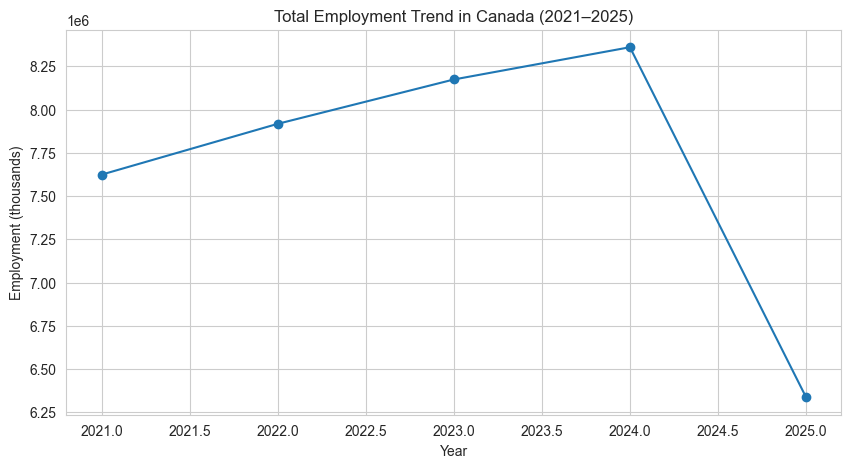

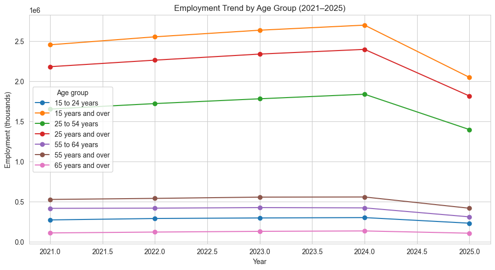

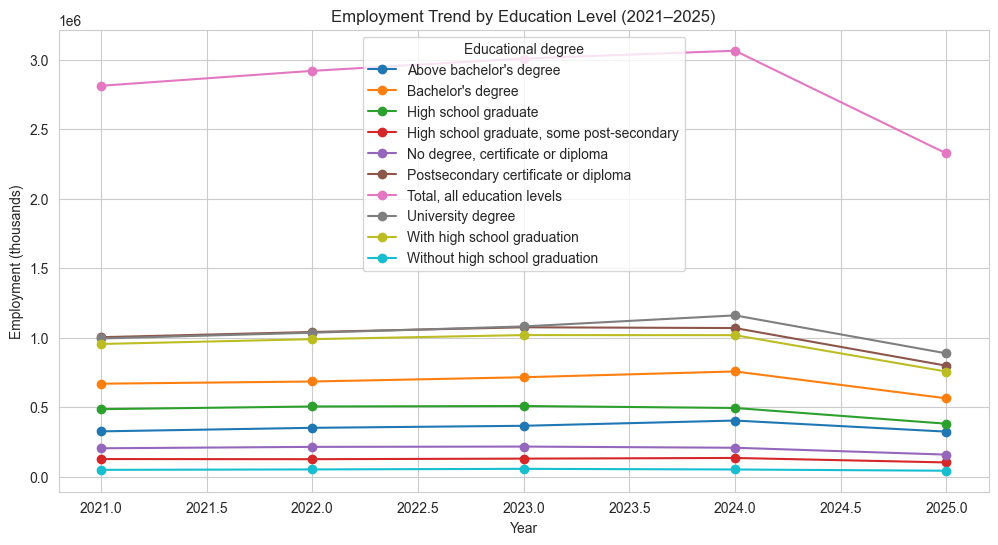

```python
# Explore unique values in key columns
print("Age groups:", employment_df['Age group'].unique())
print("Education levels:", employment_df['Educational degree'].unique())
print("Genders:", employment_df['Gender'].unique())

# Overall employment trend in Canada
employment_trend = (
    employment_df
    .groupby(employment_df['REF_DATE'].dt.year)['VALUE']
    .sum()
)
print(employment_trend)

# Plotting the employment trends
plt.figure(figsize=(10, 5))
plt.plot(employment_trend.index, employment_trend.values, marker='o')
plt.title("Total Employment Trend in Canada (2021–2025)")
plt.xlabel("Year")
plt.ylabel("Employment (thousands)")
plt.grid(True)
plt.show()


# Employment trend by age group
age_trend = (
    employment_df
    .groupby([employment_df['REF_DATE'].dt.year, 'Age group'])['VALUE']
    .sum()
    .unstack()
)

# Plotting employment trends by age group
age_trend.plot(figsize=(12, 6), marker='o')
plt.title("Employment Trend by Age Group (2021–2025)")
plt.xlabel("Year")
plt.ylabel("Employment (thousands)")
plt.grid(True)
plt.show()

#Employment trend by education level
education_trend = (
    employment_df
    .groupby([employment_df['REF_DATE'].dt.year, 'Educational degree'])['VALUE']
    .sum()
    .unstack()
)

# Plotting employment trends by education level
education_trend.plot(figsize=(12, 6), marker='o')
plt.title("Employment Trend by Education Level (2021–2025)")
plt.xlabel("Year")
plt.ylabel("Employment (thousands)")
plt.grid(True)
plt.show()
```

## 📊 Employment Trends in Canada (2021–2025): Key Observations

Overall Employment Trend:

Employment peaked in 2024.

A sharp decline occurs in 2025, indicating:

Slower hiring or hiring freezes

Economic cooling

Possible AI-driven restructuring and automation reducing labour demand

Implication

These patterns strongly align with the hypothesis that AI adoption and automation are beginning to reshape the Canadian workforce, increasing demand for skilled labour while reducing opportunities for routine and lower-skilled jobs.

## We'll now observe the unemployement data

```python
unemployment_df = EE_Wage_Trend[EE_Wage_Trend["Labour force characteristics"] == "Unemployment"].copy()
unemployment_df.head()
```

|  | REF_DATE | GEO | DGUID | Labour force characteristics | Educational degree | Gender | Age group | UOM | UOM_ID | SCALAR_FACTOR | SCALAR_ID | VECTOR | COORDINATE | VALUE | STATUS | SYMBOL | TERMINATED | DECIMALS |
| --- | --- | --- | --- | --- | --- | --- | --- | --- | --- | --- | --- | --- | --- | --- | --- | --- | --- | --- |
| 532350 | 2021-01-01 | Canada | 2021A000011124 | Unemployment | Total, all education levels | Total - Gender | 15 years and over | Persons in thousands | 428.0 | thousands | 3.0 | v54911770 | 1.6.1.1.1 | 1968.3 | NaN | NaN | NaN | 1.0 |
| 532351 | 2021-01-01 | Canada | 2021A000011124 | Unemployment | Total, all education levels | Total - Gender | 15 to 24 years | Persons in thousands | 428.0 | thousands | 3.0 | v54911771 | 1.6.1.1.2 | 509.0 | NaN | NaN | NaN | 1.0 |
| 532352 | 2021-01-01 | Canada | 2021A000011124 | Unemployment | Total, all education levels | Total - Gender | 25 years and over | Persons in thousands | 428.0 | thousands | 3.0 | v54911772 | 1.6.1.1.3 | 1459.3 | NaN | NaN | NaN | 1.0 |
| 532353 | 2021-01-01 | Canada | 2021A000011124 | Unemployment | Total, all education levels | Total - Gender | 25 to 54 years | Persons in thousands | 428.0 | thousands | 3.0 | v54911773 | 1.6.1.1.4 | 1073.8 | NaN | NaN | NaN | 1.0 |
| 532354 | 2021-01-01 | Canada | 2021A000011124 | Unemployment | Total, all education levels | Total - Gender | 55 years and over | Persons in thousands | 428.0 | thousands | 3.0 | v54911774 | 1.6.1.1.5 | 385.5 | NaN | NaN | NaN | 1.0 |

```
REF_DATE
2021    564854.6
2022    396611.9
2023    414466.2
2024    499123.0
2025    422124.3
Name: VALUE, dtype: float64
```

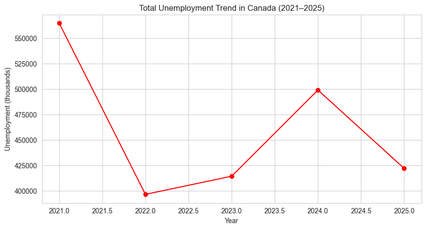

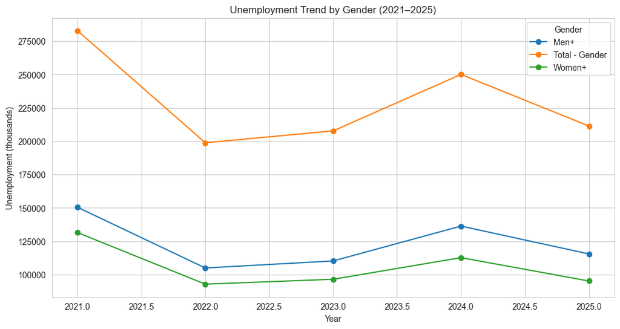

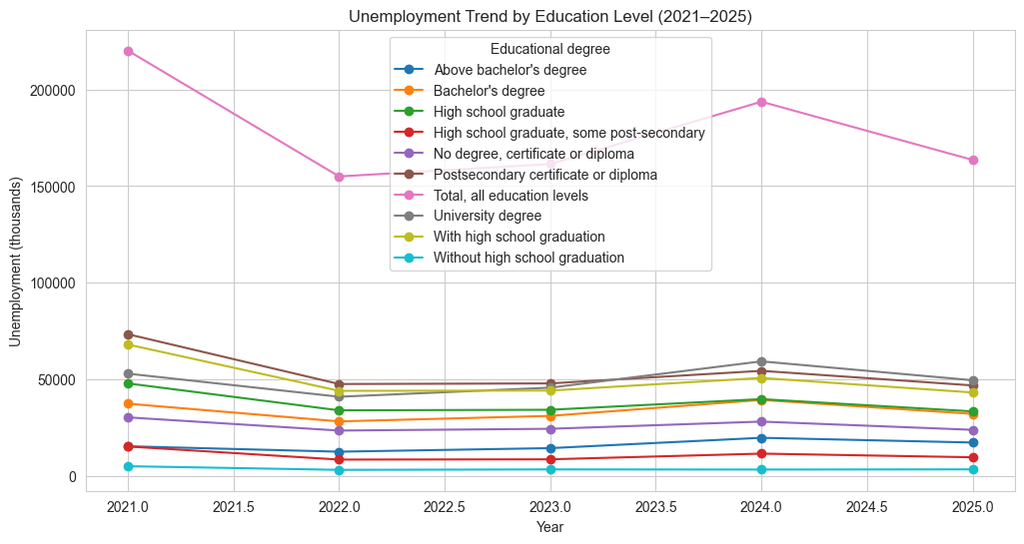

```python
# This code section will look at unemployment trends from 2021 to 2025

# Overall unemployment trend in Canada
unemployment_trend = (
    unemployment_df
    .groupby(unemployment_df['REF_DATE'].dt.year)['VALUE']
    .sum()
)

# print data size of unemployment trend
print(unemployment_trend)


# Plotting the unemployment trends
plt.figure(figsize=(10, 5))
plt.plot(unemployment_trend.index, unemployment_trend.values, marker='o', color='red')
plt.title("Total Unemployment Trend in Canada (2021–2025)")
plt.xlabel("Year")
plt.ylabel("Unemployment (thousands)")
plt.grid(True)
plt.show()

# Unemployment trend by gender
gender_trend = (
    unemployment_df
    .groupby([unemployment_df['REF_DATE'].dt.year, 'Gender'])['VALUE']
    .sum()
    .unstack()
)
gender_trend.plot(figsize=(12, 6), marker='o')
plt.title("Unemployment Trend by Gender (2021–2025)")
plt.xlabel("Year")
plt.ylabel("Unemployment (thousands)")
plt.grid(True)
plt.show()

# Employment trend by education level
education_unemp_trend = (
    unemployment_df
    .groupby([unemployment_df['REF_DATE'].dt.year, 'Educational degree'])['VALUE']
    .sum()
    .unstack()
)
education_unemp_trend.plot(figsize=(12, 6), marker='o')
plt.title("Unemployment Trend by Education Level (2021–2025)")
plt.xlabel("Year")
plt.ylabel("Unemployment (thousands)")
plt.grid(True)
plt.show()
```

## 📉 Unemployment Trends in Canada (2021–2025): Key Observations

Overall Unemployment Trend

Unemployment dropped sharply from 2021 to 2022, reflecting economic recovery after the COVID shock.

A slight uptick occurs in 2023–2024, suggesting early signs of labour market softening. 2025 shows a decline again, but still higher than the lowest point in 2022.

What This Implies

- The recovery phase (2021→2022) shows strong rehiring and economic stabilization.
- The rise in 2023–2024 signals slower job creation, economic cooling, and potential structural changes.
- The mix of decline + volatility suggests the labour market is tightening, not simply fluctuating.

The unemployment data shows that:

- Recovery (2021–2022) was strong.
- Pressure increases (2023–2024) indicate cooling labour demand.
- Education level becomes a major buffer, with low-education groups facing the biggest risk.
- These patterns align with AI and automation replacing routine work, while boosting demand for skilled and educated workers.

# We'll now examine employement and unemployment rates

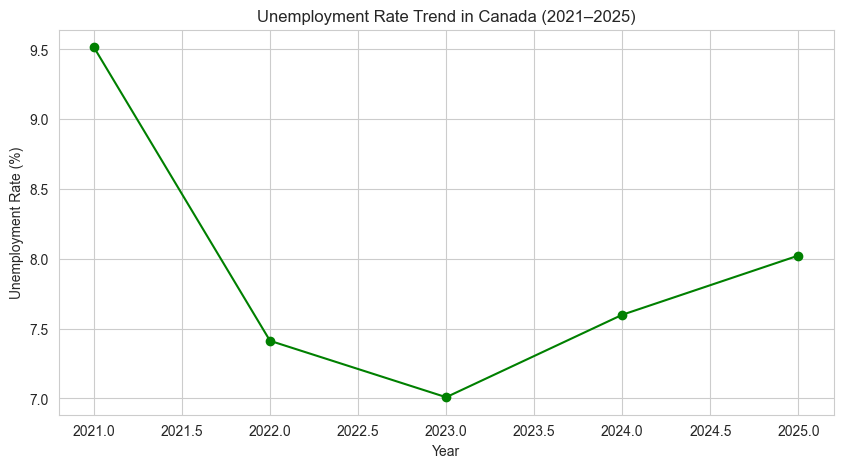

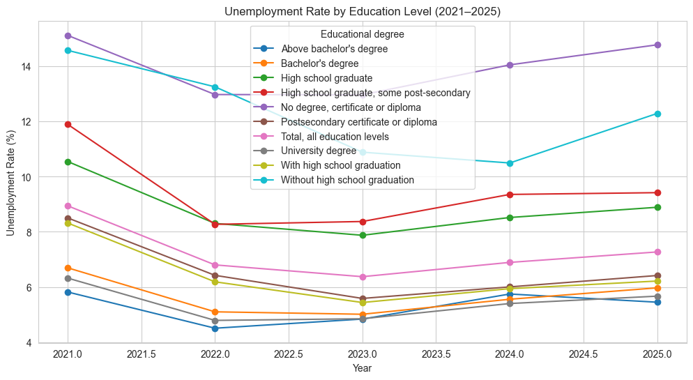

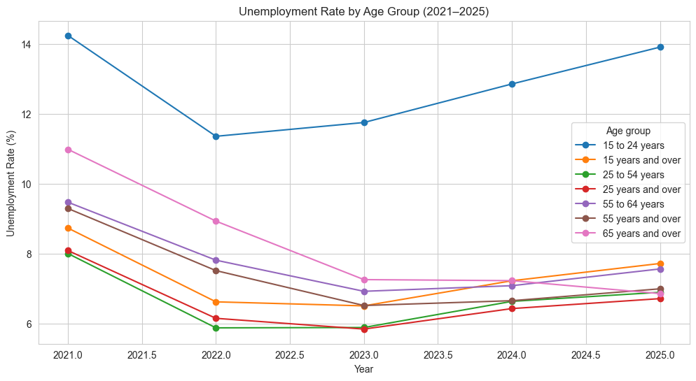

```python
# Copy of unemployment rate data
unemployment_rate = EE_Wage_Trend[EE_Wage_Trend["Labour force characteristics"] == "Unemployment rate"].copy()
unemployment_rate.head()
unemployment_rate_trend = (
    unemployment_rate
    .groupby(unemployment_rate['REF_DATE'].dt.year)['VALUE']
    .mean()
)

# Plotting the unemployment rate trend
unemployment_rate_trend.plot(figsize=(10, 5), marker='o', color='green')
plt.title("Unemployment Rate Trend in Canada (2021–2025)")
plt.xlabel("Year")
plt.ylabel("Unemployment Rate (%)")
plt.grid(True)
plt.show()

# Unemployment rate by education level
education_unemp_rate_trend = (
    unemployment_rate
    .groupby([unemployment_rate['REF_DATE'].dt.year, 'Educational degree'])['VALUE']
    .mean()
    .unstack()
)

# Plotting the unemployment rate by education level
education_unemp_rate_trend.plot(figsize=(12, 6), marker='o')
plt.title("Unemployment Rate by Education Level (2021–2025)")
plt.xlabel("Year")
plt.ylabel("Unemployment Rate (%)")
plt.grid(True)
plt.show()

# Unemployment rate by age group
age_unemp_rate_trend = (
    unemployment_rate
    .groupby([unemployment_rate['REF_DATE'].dt.year, 'Age group'])['VALUE']
    .mean()
    .unstack()
)
age_unemp_rate_trend.plot(figsize=(12, 6), marker='o')
plt.title("Unemployment Rate by Age Group (2021–2025)")
plt.xlabel("Year")
plt.ylabel("Unemployment Rate (%)")
plt.grid(True)
plt.show()
```

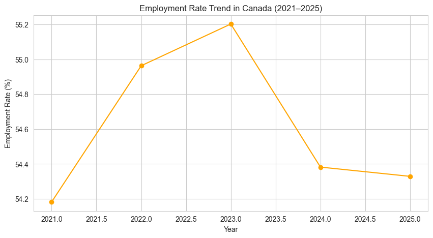

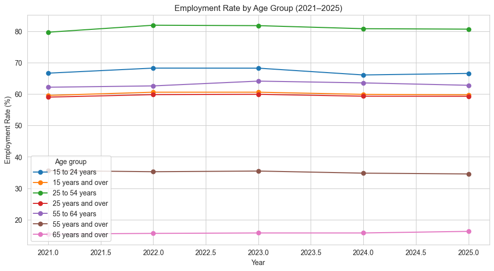

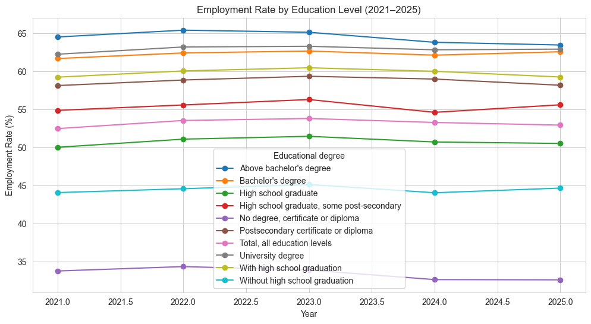

```python
# Employment Rate Trend
employment_rate_df = EE_Wage_Trend[EE_Wage_Trend["Labour force characteristics"] == "Employment rate"].copy()
employment_rate_trend = (
    employment_rate_df
    .groupby(employment_rate_df['REF_DATE'].dt.year)['VALUE']
    .mean()
)
employment_rate_trend

# Plotting the employment rate trend
plt.figure(figsize=(10, 5))
plt.plot(employment_rate_trend.index, employment_rate_trend.values, marker='o', color='orange')
plt.title("Employment Rate Trend in Canada (2021–2025)")
plt.xlabel("Year")
plt.ylabel("Employment Rate (%)")
plt.grid(True)
plt.show()

# Employment rate by Age Group
age_rate_trend = (
    employment_rate_df
    .groupby([employment_rate_df['REF_DATE'].dt.year, 'Age group'])['VALUE']
    .mean()
    .unstack()
)
age_rate_trend.plot(figsize=(12, 6), marker='o')
plt.title("Employment Rate by Age Group (2021–2025)")
plt.xlabel("Year")
plt.ylabel("Employment Rate (%)")
plt.grid(True)
plt.show()

# Employment rate by Education Level
education_rate_trend = (
    employment_rate_df
    .groupby([employment_rate_df['REF_DATE'].dt.year, 'Educational degree'])['VALUE']
    .mean()
    .unstack()
)
education_rate_trend.plot(figsize=(12, 6), marker='o')
plt.title("Employment Rate by Education Level (2021–2025)")
plt.xlabel("Year")
plt.ylabel("Employment Rate (%)")
plt.grid(True)
plt.show()
```

### 1. Higher-educated workers remain protected

Workers with university or above-bachelor's degrees show high and stable employment rates across all years. Why?

- AI complements highly skilled labour
- Higher demand for tech-literate professionals
- Growth in AI-enabled sectors (tech, finance, engineering, analytics)
- AI increases the value of high-skill labour rather than replacing it. (Potentially?)

### 2. Lower-education groups show signs of early displacement

Workers with no diploma, high school only, or partial post-secondary experience flat or declining employment rates after 2023. Why?

- These groups work in roles that AI automates first:
- Routine administrative tasks
- Customer service
- Basic service roles
- Repetitive clerical or processing work
- AI pressure appears strongest on routine, lower-skill jobs.

### 3. Younger workers face more volatility

- They are heavily employed in:
- Retail
- Food service
- Entry-level office roles
- Customer support
- AI reduces entry-level opportunities, making it harder for youth to enter stable employment.

### 4. Prime-age workers (25–54) remain stable

- This group shows minimal disruption, suggesting:
- Experience and adaptability protect them
- Their roles involve judgment, leadership, and complex decision-making
- AI augments but does not replace them (yet)
- AI currently complements mid-career workers more than replacing them.

### 5. 2025 slowdown aligns with an AI-driven shift

This pattern matches early-stage AI adoption

- Less demand for repetitive labour
- Slower hiring for entry-level and routine tasks
- Increased productivity reducing headcount needs
- Higher demand for specialized, highly skilled workers

Overall Summary

# We'll now take a look at labour force participation

What is the labour force? The labour force includes **everyone who is working or actively looking for work**.  
It does *not* include retirees, full-time students who aren’t job searching, or discouraged workers who stopped looking.

```
['Population' 'Labour force' 'Employment' 'Full-time employment'
 'Part-time employment' 'Unemployment' 'Not in labour force'
 'Unemployment rate' 'Participation rate' 'Employment rate']
```

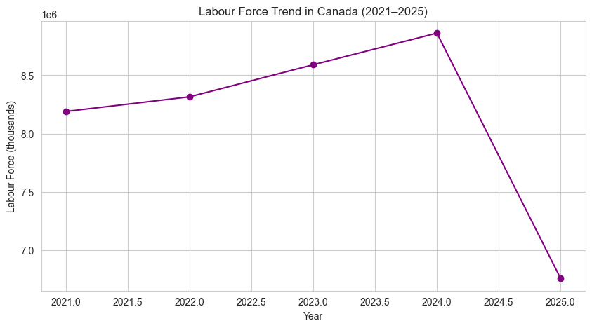

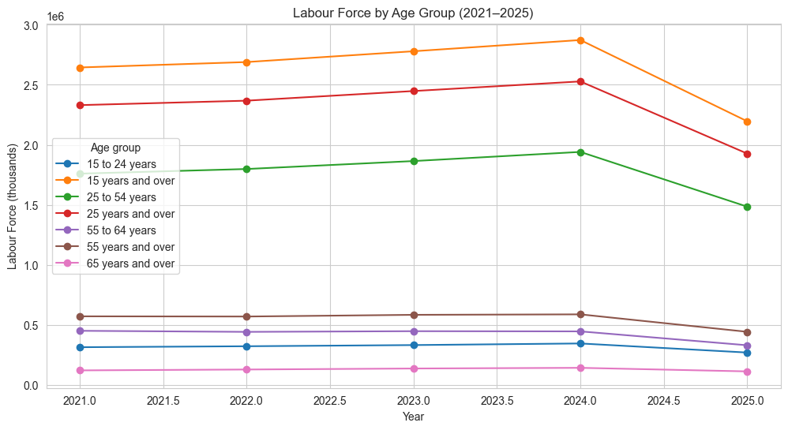

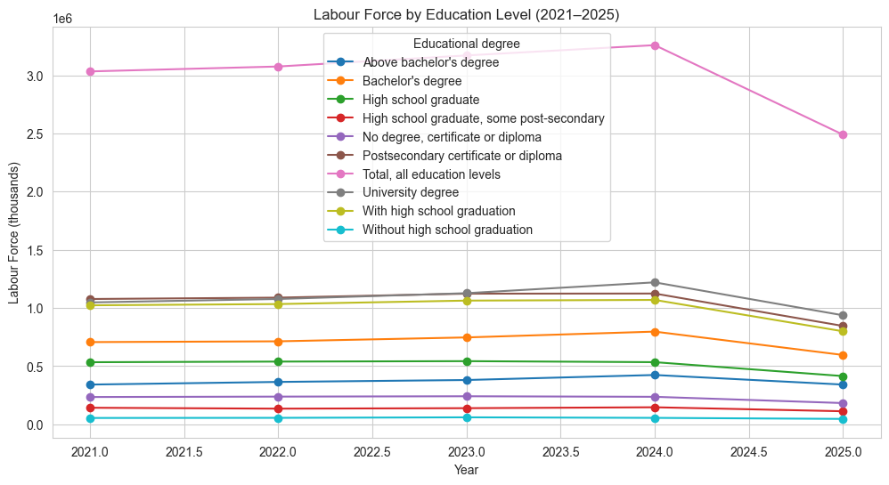

```python
#print out all labour force characteristics
print(EE_Wage_Trend['Labour force characteristics'].unique())

Labour_force_Participation = EE_Wage_Trend[EE_Wage_Trend["Labour force characteristics"] == "Labour force"].copy()
Labour_force_Participation.head()

labour_force_trend = (
    Labour_force_Participation
    .groupby(Labour_force_Participation['REF_DATE'].dt.year)['VALUE']
    .sum()
)
labour_force_trend
# Plotting the labour force trend
plt.figure(figsize=(10, 5))
plt.plot(labour_force_trend.index, labour_force_trend.values, marker='o', color='purple')
plt.title("Labour Force Trend in Canada (2021–2025)")
plt.xlabel("Year")
plt.ylabel("Labour Force (thousands)")
plt.grid(True)
plt.show()

# labour force by age group
age_labour_trend = (
    Labour_force_Participation
    .groupby([Labour_force_Participation['REF_DATE'].dt.year, 'Age group'])['VALUE']
    .sum()
    .unstack()
)
age_labour_trend.plot(figsize=(12, 6), marker='o')
plt.title("Labour Force by Age Group (2021–2025)")
plt.xlabel("Year")
plt.ylabel("Labour Force (thousands)")
plt.grid(True)
plt.show()

# labour force by education level
education_labour_trend = (
    Labour_force_Participation
    .groupby([Labour_force_Participation['REF_DATE'].dt.year, 'Educational degree'])['VALUE']
    .sum()
    .unstack()
)
education_labour_trend.plot(figsize=(12, 6), marker='o')
plt.title("Labour Force by Education Level (2021–2025)")
plt.xlabel("Year")
plt.ylabel("Labour Force (thousands)")
plt.grid(True)
plt.show()
```

## 📈 2021–2024: Steady Growth

From 2021 to 2024, Canada’s labour force **grew consistently**, reflecting:

- Strong population and immigration growth
- Post-COVID economic recovery
- High job availability
- Increased confidence in the job market

More people felt motivated to seek work.

## 2025: Sharp and Unusual Decline

The labour force drops sharply in 2025 — the largest decline in the entire period.

### **2. AI and automation pressure**

If AI reduces demand for administrative, clerical, or basic service roles, displaced workers may:

- Give up job searching
- Go back to school
- Shift to informal work
- Retire early

### **3. Economic cooling or hiring freezes**

Companies reducing hiring can decrease participation.

### **4. Youth delaying entry**

Young workers may remain in school longer if job prospects weaken.

## Summary

- rising unemployment for some groups
- falling employment for low-education and youth groups
- evidence of automation and AI beginning to reshape the labour market

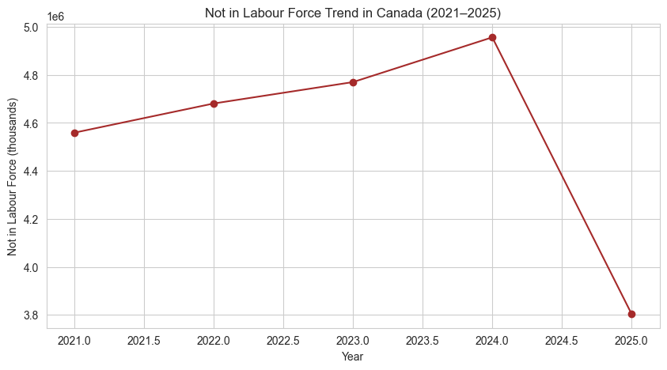

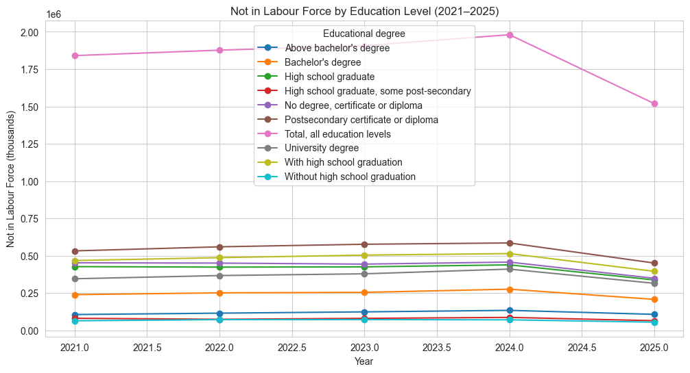

```python
EE_Wage_Trend["Labour force characteristics"].unique()

# get the not in labour force data
not_in_labour_force = EE_Wage_Trend[EE_Wage_Trend["Labour force characteristics"] == "Not in labour force"].copy()
not_in_labour_force.head()

not_in_labour_trend = (
    not_in_labour_force
    .groupby(not_in_labour_force['REF_DATE'].dt.year)['VALUE']
    .sum()
)
not_in_labour_trend
# Plotting the not in labour force trend
plt.figure(figsize=(10, 5))
plt.plot(not_in_labour_trend.index, not_in_labour_trend.values, marker='o', color='brown')
plt.title("Not in Labour Force Trend in Canada (2021–2025)")
plt.xlabel("Year")
plt.ylabel("Not in Labour Force (thousands)")
plt.grid(True)
plt.show()

# not in labour force by education level
education_not_in_labour_trend = (
    not_in_labour_force
    .groupby([not_in_labour_force['REF_DATE'].dt.year, 'Educational degree'])['VALUE']
    .sum()
    .unstack()
)
education_not_in_labour_trend.plot(figsize=(12, 6), marker='o')
plt.title("Not in Labour Force by Education Level (2021–2025)")
plt.xlabel("Year")
plt.ylabel("Not in Labour Force (thousands)")
plt.grid(True)
plt.show()
```

# Shifting focus to the use of AI by Businesses, by Industry

```python
AI_use_df = pd.read_csv("data/33100878.csv")
print(AI_use_df.head())
print(AI_use_df.columns)
print(AI_use_df.shape)
```

```
   REF_DATE     GEO           DGUID                           Business characteristics Use of artificial intelligence (AI) by businesses or organizations in producing goods or delivering services over the next 12 months      UOM  UOM_ID SCALAR_FACTOR  SCALAR_ID       VECTOR COORDINATE  VALUE STATUS …
0      2024  Canada  2021A000011124  North American Industry Classification System ...  Yes, business plans to use AI for producing go...                                                                                    Percent     239         units          0  v1594336625      1.1.1   10.6      A …
1      2024  Canada  2021A000011124  North American Industry Classification System ...  Type of AI application planned to use, machine...                                                                                    Percent     239         units          0  v1594336636      1.1.2   18.8      B …
2      2024  Canada  2021A000011124  North American Industry Classification System ...  Type of AI application planned to use, natural...                                                                                    Percent     239         units          0  v1594336639      1.1.3   15.4      B …
3      2024  Canada  2021A000011124  North American Industry Classification System ...  Type of AI application planned to use, virtual...                                                                                    Percent     239         units          0  v1594336640      1.1.4   18.7      B …
4      2024  Canada  2021A000011124  North American Industry Classification System ...  Type of AI application planned to use, speech ...                                                                                    Percent     239         units          0  v1594336641      1.1.5   11.9      B …
Index(['REF_DATE', 'GEO', 'DGUID', 'Business characteristics', 'Use of artificial intelligence (AI) by businesses or organizations in producing goods or delivering services over the next 12 months', 'UOM', 'UOM_ID', 'SCALAR_FACTOR', 'SCALAR_ID', 'VECTOR', 'COORDINATE', 'VALUE', 'STATUS', 'SYMBOL', '…
(19698, 16)
```

```python
# get the businesses characteristics related to AI use
print(AI_use_df["Business characteristics"].unique())

print("-----------")
print(AI_use_df["Use of artificial intelligence (AI) by businesses or organizations in producing goods or delivering services over the next 12 months"].unique())
```

```
['North American Industry Classification System (NAICS), all industries'
 'Agriculture, forestry, fishing and hunting [11]'
 'Mining, quarrying, and oil and gas extraction [21]' 'Construction [23]'
 'Manufacturing [31-33]' 'Wholesale trade [41]' 'Retail trade [44-45]'
 'Transportation and warehousing [48-49]'
 'Information and cultural industries [51]' 'Finance and insurance [52]'
 'Real estate and rental and leasing [53]'
 'Professional, scientific and technical services [54]'
 'Administrative and support, waste management and remediation services [56]'
 'Health care and social assistance [62]'
 'Arts, entertainment and recreation [71]'
 'Accommodation and food services [72]'
 'Other services (except public administration) [81]'
 'Business or organization size of employment, all employment sizes'
 '1 to 4 employees' '5 to 19 employees' '20 to 99 employees'
 '100 or more employees'
 'Business or organization type, all businesses or organizations'
 'Government agencies' 'Private sector businesses'
 'Non-profit organizations'
 'Non-profit organizations serving households or individuals'
 'Non-profit organizations serving businesses'
 'Age of business or organization, all ages'
 'Age of business or organization, 2 years or less'
 'Age of business or organization, 3 to 10 years old'
 'Age of business or organization, 11 to 20 years old'
 'Age of business or organization, more than 20 years old'
 'Geography, all geography' 'Urban' 'Rural'
 'Majority ownership, all ownerships' 'Majority ownership, woman'
 'Majority ownership, First Nations, Métis or Inuit'
 'Majority ownership, immigrant to Canada'
 'Majority ownership, person with a disability'
 'Majority ownership, LGBTQ2 people'
 'Majority ownership, visible minority'
 'Ownership by visible minority, all visible minorities'
 'Ownership by visible minority, South Asian'
 'Ownership by visible minority, Chinese'
 'Ownership by visible minority, Black'
 'Ownership by visible minority, Filipino'
 'Ownership by visible minority, Latin American'
 'Ownership by visible minority, Arab'
```

[output cut: 23 more lines]

```
 'Type of AI application planned to use, large language models'
 'Type of AI application planned to use, text analytics using AI'
 'Type of AI application planned to use, data analytics using AI'
 'Type of AI application planned to use, neural network'
 'Type of AI application planned to use, augmented reality'
 'Type of AI application planned to use, decision making systems based on AI'
 'Type of AI application planned to use, deep learning'
 'Type of AI application planned to use, image or pattern recognition'
 'Type of AI application planned to use, machine or computer vision'
 'Type of AI application planned to use, robotics process automation'
 'Type of AI application planned to use, biometrics'
 'Type of AI application planned to use, marketing automation using AI'
 'Type of AI application planned to use, other type'
 'No, business or organization does not plan to use AI for producing goods or delivering services over the next 12 months'
 'Use of AI by businesses or organizations in producing goods or delivering services over the next 12 months, unknown']
```

```python
#shorten the column name for easier access
from ast import For

AI_use_df = AI_use_df.rename(columns={"Use of artificial intelligence (AI) by businesses or organizations in producing goods or delivering services over the next 12 months": "AI Use Next 12 Months"})

def clean_ai_label(text):

    # 1. Handle "YES"
    if text.startswith("Yes, business plans to use AI"):
        return "Producing goods & services"

    # 2. Handle "NO"
    if text.startswith("No, business or organization does not plan"):
        return "No use"

    # 3. Handle "UNKNOWN"
    if "unknown" in text.lower():
        return "Unknown"

    # 4. Handle all "Type of AI application planned to use, X"
    if "Type of AI application planned to use" in text:
        # I WANT EVERYTHING AFTER THE , NOT JUST THE FIRST WORD
        parts = text.split(",")
        if len(parts) > 1:
            return parts[1].strip()

    # 5. Fallback
    return text.split(" ")[0]



AI_use_df["AI Use Next 12 Months"] = AI_use_df["AI Use Next 12 Months"].apply(clean_ai_label)

print(AI_use_df["AI Use Next 12 Months"].unique())
```

```
['Producing goods & services' 'machine learning'
 'natural language processing' 'virtual agents or chatbots'
 'speech or voice recognition using AI' 'recommendation systems using AI'
 'large language models' 'text analytics using AI'
 'data analytics using AI' 'neural network' 'augmented reality'
 'decision making systems based on AI' 'deep learning'
 'image or pattern recognition' 'machine or computer vision'
 'robotics process automation' 'biometrics'
 'marketing automation using AI' 'other type' 'No use' 'Unknown']
```

[figure not shown]

```python
ai_use_trend = (
    AI_use_df
    .groupby('AI Use Next 12 Months')['VALUE']
    .sum()
    .sort_values(ascending=False)
)

ax = ai_use_trend.plot(kind='bar', figsize=(14, 7))
ax.set_title("AI Use by Businesses Over 2024 (12 months)")
ax.set_xlabel("AI Use Category")
ax.set_ylabel("Number of Businesses")
ax.grid(True)
plt.tight_layout()

# rotate x labels for better readability
ax.set_xticklabels(ax.get_xticklabels(), rotation=45, ha='right')
plt.show()
```